# Bank stocks monitoring

Nel Antuña

17/12/2020

# Introduction

### Purpose

This project is an app pilot whose purpose will be to monitor de performance of a series of company stocks.

In this pilot we will consider the performance of the shares of 3 Spanish banks in Ibex-35, the main Spanish index, during a period of time.

### Agenda

In this presentation we will review:

1. What data was consired
2. How data was obtained
3. The output of the app

# The data

### Stocks

Companies used for this pilot project are

- Santander Bank
- BBVA
- CaixaBank

The three of them are top-3 banks in Spain.

### Time span

For time reference, three periods of time have been considered:

- Last 5 days
- Last 15 days
- Last month

# The data source

Data is being imported Yahoo Finance website using “Tidyquant” library

```r
library(tidyquant)
data <- tq_get(c("BBVA.MC", "SAN.MC", "CABK.MC"),
        get = "stock.prices",
        from = today()-30,
        to = today())
head(data,3)
```

```
## # A tibble: 3 x 8
##   symbol  date        open  high   low close   volume adjusted
##   <chr>   <date>     <dbl> <dbl> <dbl> <dbl>    <dbl>    <dbl>
## 1 BBVA.MC 2020-11-17  3.62  3.64  3.39  3.50 53349717     3.50
## 2 BBVA.MC 2020-11-18  3.49  3.55  3.43  3.51 28293824     3.51
## 3 BBVA.MC 2020-11-19  3.43  3.60  3.43  3.57 25851326     3.57
```

The data is then manipulated depending on the input of the user, which can be on two ways:

- The banks to be plotted
- The length of period of time considered

# The output

Once the user selects the desired input and clicks on submit, the data will be plotted.

Below an example with the three banks and for last month:

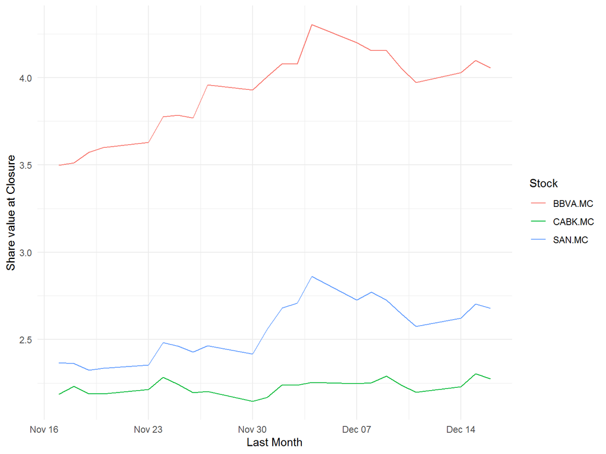